# 카이제곱검정

kuma987

2022년 January 08일

# 적합성 검정

관찰되는 실제적인 도수들이 우리가 가정한 확률분포에 얼마나 일치하는 지 검정

귀무가설 : 관촬된 도수들이 가정한 확률분포를 따른다

## 사용 데이터

```r
# 관측값
O <- c(26, 30, 26, 18, 9, 11)
# 기대확률
P <- c(0.143, 0.279, 0.274, 0.175, 0.085, 0.044)
```

## 검정 수행

```r
# rescale.p : p의 합이 1이여야 하는데, 그렇지 않을 경우 합이 1이 되도록 변환
result <- chisq.test(x = O, p=P, rescale.p = TRUE)
# p-value가 0.05보다 크면 가정한 확률분포를 따른다고 해석
result
```

```
##
##  Chi-squared test for given probabilities
##
## data:  O
## X-squared = 13.122, df = 5, p-value = 0.02226
```

# 독립성 검정

여러 범주를 가지는 두 개의 범주형 변수가 독립적인지, 서로 연관성이 있는지 검정

귀무가설 : 서로 독립이다

## 사용 데이터

```r
dat <- read.csv('/Users/JGH/Desktop/github/R-Notebook/data/homogenity.csv')
dat <- dat[,c('method','survey')]
dat$method <- factor(dat$method)
dat$survey <- factor(dat$survey)
head(dat)
```

```
##   method survey
## 1      1      1
## 2      2      2
## 3      3      3
## 4      1      4
## 5      2      5
## 6      3      2
```

## 검정 수행

```r
library(gmodels)
```

```r
CrossTable(dat$method, dat$survey)
```

```
##
##
##    Cell Contents
## |-------------------------|
## |                       N |
## | Chi-square contribution |
## |           N / Row Total |
## |           N / Col Total |
## |         N / Table Total |
## |-------------------------|
##
##
## Total Observations in Table:  150
##
##
##              | dat$survey
##   dat$method |         1 |         2 |         3 |         4 |         5 | Row Total |
## -------------|-----------|-----------|-----------|-----------|-----------|-----------|
##            1 |         5 |         8 |        15 |        16 |         6 |        50 |
##              |     0.571 |     0.287 |     0.577 |     0.286 |     0.143 |           |
##              |     0.100 |     0.160 |     0.300 |     0.320 |     0.120 |     0.333 |
##              |     0.238 |     0.276 |     0.405 |     0.381 |     0.286 |           |
##              |     0.033 |     0.053 |     0.100 |     0.107 |     0.040 |           |
## -------------|-----------|-----------|-----------|-----------|-----------|-----------|
##            2 |         8 |        14 |        11 |        11 |         6 |        50 |
##              |     0.143 |     1.943 |     0.144 |     0.643 |     0.143 |           |
##              |     0.160 |     0.280 |     0.220 |     0.220 |     0.120 |     0.333 |
##              |     0.381 |     0.483 |     0.297 |     0.262 |     0.286 |           |
##              |     0.053 |     0.093 |     0.073 |     0.073 |     0.040 |           |
## -------------|-----------|-----------|-----------|-----------|-----------|-----------|
##            3 |         8 |         7 |        11 |        15 |         9 |        50 |
##              |     0.143 |     0.736 |     0.144 |     0.071 |     0.571 |           |
##              |     0.160 |     0.140 |     0.220 |     0.300 |     0.180 |     0.333 |
##              |     0.381 |     0.241 |     0.297 |     0.357 |     0.429 |           |
##              |     0.053 |     0.047 |     0.073 |     0.100 |     0.060 |           |
## -------------|-----------|-----------|-----------|-----------|-----------|-----------|
## Column Total |        21 |        29 |        37 |        42 |        21 |       150 |
##              |     0.140 |     0.193 |     0.247 |     0.280 |     0.140 |           |
## -------------|-----------|-----------|-----------|-----------|-----------|-----------|
##
##
```

```r
# p-value가 0.05보다 크면 서로 독립이다
chisq.test(dat$method, dat$survey)
```

```
##
##  Pearson's Chi-squared test
##
## data:  dat$method and dat$survey
## X-squared = 6.5447, df = 8, p-value = 0.5865
```

# 동질성 검정

하나의 범주형 변수를 기준으로, 각 그룹이 다른 범주형 변수에 분포가 동일한 성질을 띄는지 검정 (분포가 비슷한가 확인)

귀무가설 : 동질성을 가진다 (분포에 차이가 없다)

## 사용 데이터

```r
dat <- read.csv('/Users/JGH/Desktop/github/R-Notebook/data/homogenity.csv')
dat <- dat[,c('method','survey')]
dat$method <- factor(dat$method)
dat$survey <- factor(dat$survey)
head(dat)
```

```
##   method survey
## 1      1      1
## 2      2      2
## 3      3      3
## 4      1      4
## 5      2      5
## 6      3      2
```

## 검정 수행

```r
library(gmodels)
```

```r
CrossTable(dat$method, dat$survey)
```

```
##
##
##    Cell Contents
## |-------------------------|
## |                       N |
## | Chi-square contribution |
## |           N / Row Total |
## |           N / Col Total |
## |         N / Table Total |
## |-------------------------|
##
##
## Total Observations in Table:  150
##
##
##              | dat$survey
##   dat$method |         1 |         2 |         3 |         4 |         5 | Row Total |
## -------------|-----------|-----------|-----------|-----------|-----------|-----------|
##            1 |         5 |         8 |        15 |        16 |         6 |        50 |
##              |     0.571 |     0.287 |     0.577 |     0.286 |     0.143 |           |
##              |     0.100 |     0.160 |     0.300 |     0.320 |     0.120 |     0.333 |
##              |     0.238 |     0.276 |     0.405 |     0.381 |     0.286 |           |
##              |     0.033 |     0.053 |     0.100 |     0.107 |     0.040 |           |
## -------------|-----------|-----------|-----------|-----------|-----------|-----------|
##            2 |         8 |        14 |        11 |        11 |         6 |        50 |
##              |     0.143 |     1.943 |     0.144 |     0.643 |     0.143 |           |
##              |     0.160 |     0.280 |     0.220 |     0.220 |     0.120 |     0.333 |
##              |     0.381 |     0.483 |     0.297 |     0.262 |     0.286 |           |
##              |     0.053 |     0.093 |     0.073 |     0.073 |     0.040 |           |
## -------------|-----------|-----------|-----------|-----------|-----------|-----------|
##            3 |         8 |         7 |        11 |        15 |         9 |        50 |
##              |     0.143 |     0.736 |     0.144 |     0.071 |     0.571 |           |
##              |     0.160 |     0.140 |     0.220 |     0.300 |     0.180 |     0.333 |
##              |     0.381 |     0.241 |     0.297 |     0.357 |     0.429 |           |
##              |     0.053 |     0.047 |     0.073 |     0.100 |     0.060 |           |
## -------------|-----------|-----------|-----------|-----------|-----------|-----------|
## Column Total |        21 |        29 |        37 |        42 |        21 |       150 |
##              |     0.140 |     0.193 |     0.247 |     0.280 |     0.140 |           |
## -------------|-----------|-----------|-----------|-----------|-----------|-----------|
##
##
```

```r
# p-value가 0.05보다 크면 동질하다
chisq.test(dat$method,dat$survey)
```

```
##
##  Pearson's Chi-squared test
##
## data:  dat$method and dat$survey
## X-squared = 6.5447, df = 8, p-value = 0.5865
```

```r
library(ggplot2)
```

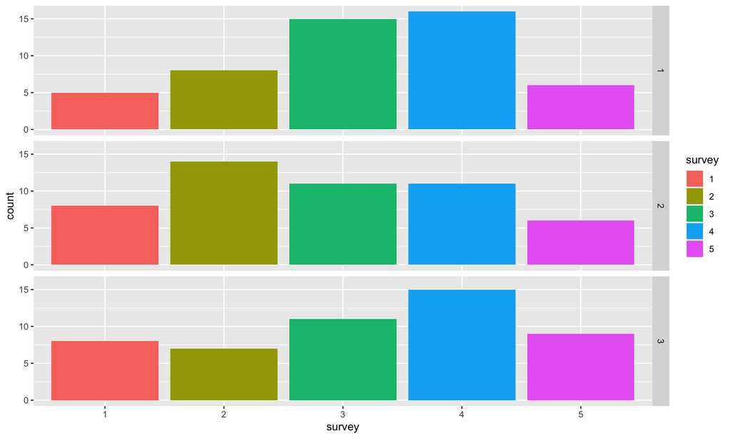

```r
# 시각화하여 확인
ggplot(dat) + geom_bar(aes(x=survey, fill=survey)) + facet_grid(method~.)
```

# 독립성 검정과 동질성 검정의 비교

가설 설정 부분만 차이가 날 뿐, 검정 수행 부분은 동일하게 진행된다

개념적 해석  
독립성 검정은 하나의 모집단에서 표본추출하지만,  
동질성 검정은 두 개 이상의 모집단에서 표본추출하여 분할표를 생성한다

실제 수행한 것에서 해석  
독립성 검정에서는 주어진 데이터가 하나의 표본이며, method와 survey를 각각의 요인으로 보고 두 요인이 독립인지 검증  
동질성 검정에서는 method 별로 모집단이 존재 (3개의 모집단)  
이러한 모집단에서 각각 표본추출한 3개의 표본 데이터를 결합한 형태가 주어진 데이터이며,  
survey라는 요인에 대해서 각 집단별로 동일한 성질을 보이는지 검증